# ML-M1b: g-computation and p-score introduction

Published

August 3, 2025

# 1 Packages

# 2 Introduction

**Two main methods for causal inference to obtain ATE**

**Two main approaches to estimate the Average Treatment Effect (ATE)** in causal inference from observational data are:

1. **Outcome modeling** methods, such as **G-computation** (marginal standardization),
2. **Treatment modeling** methods, such as **propensity score-based weighting** (e.g., inverse probability weighted logistic regression).

These represent two **broad classes** of causal estimation strategies.

## 2.1 More Formal Classification (with Terminology)

| Broad Approach | Specific Method | Example |
| --- | --- | --- |
| **Outcome modeling** (also called g-formula or standardization) | **G-computation** | Fit outcome model and simulate $Y(1)$, $Y(0)$ |
| **Treatment modeling** | **Inverse Probability Weighting (IPW)** | Estimate propensity scores and reweight |
| **Doubly robust** | **Augmented IPW (AIPW)**, **TMLE** | Combines both models |

## 2.2 Brief Comparison

| Feature | **G-Computation** | **IPW (Propensity Score Weighting)** |
| --- | --- | --- |
| Core Idea | Model the outcome: $E[Y \mid A, C]$] | Model the treatment: $P(A \mid C)$ |
| Requires outcome model? | ✅ Yes | ❌ Not directly |
| Requires treatment model? | ❌ No | ✅ Yes (propensity score) |
| Uses weights? | ❌ No | ✅ Yes (inverse of PS or stabilized weights) |
| Estimate type | Marginal (average) potential outcomes | Marginal ATE via weighted sample |
| Key Assumption | Outcome model is correctly specified | Propensity score model is correctly specified |
| Sensitive to | Outcome model misspecification | Extreme or poorly estimated PS (e.g., near 0 or 1) |
| Extensions | Standardization, risk difference, ICE curves | Stabilized IPW, overlap weights, etc. |
| Inference | Straightforward (bootstrap or delta method) | Needs robust SEs due to heteroskedasticity |

## 2.3 Summary

> In causal inference, two primary approaches for estimating the Average Treatment Effect (ATE) are:  
> (1) **G-computation**, an outcome modeling approach that simulates potential outcomes via a regression model, and  
> (2) **Propensity score-based inverse probability weighting (IPW)**, a treatment modeling approach that reweights the data to mimic a randomized experiment.

Both methods estimate **marginal causal effects** and rely on different modeling assumptions. They can also be **combined** in **doubly robust** estimators like AIPW or TMLE, which remain consistent if either model is correctly specified.

# 3 Conditionally Adjusted Parametric Regression

## 3.1 Data

> **Epidemiologic Follow-Up Study Data (nhefs.csv)**
> - These data were obtained from **Hernán and Robins** (Hernán and Robins, 2020).
> - A subset of these data will be used to estimate the effect of quitting smoking on weight change (in kg) between 1971 and 1982.

| **Variables** | **Description** |
| --- | --- |
| seqn |  |
| **qsmk** | **1 = Yes, 0 = No** |
| sex |  |
| age |  |
| income |  |
| sbp | Systolic BP |
| dbp | Diastolic BP |
| price71 |  |
| tax71 |  |
| race |  |
| **wt82_71** | **Weight change in kg** |

## 3.2 Model

```r
nhefs <- read_csv(here("data", "nhefs.csv")) %>%
mutate(wt_delta = as.numeric(wt82_71 > median(wt82_71)))


formulaVars <- "qsmk + sex + age + income + sbp + dbp + price71 + tax71 + race"
modelForm <- as.formula(paste("wt_delta ~",formulaVars))

modelForm
```

```
wt_delta ~ qsmk + sex + age + income + sbp + dbp + price71 +
    tax71 + race
```

```r
modelOR <- glm(modelForm, data = nhefs, family = binomial("logit"))
summary(modelOR)
```

```
Call:
glm(formula = modelForm, family = binomial("logit"), data = nhefs)

Coefficients:
             Estimate Std. Error z value Pr(>|z|)
(Intercept) -0.822736   1.178775  -0.698 0.485203
qsmk         0.594853   0.133325   4.462 8.13e-06 ***
sex          0.126227   0.113976   1.107 0.268084
age         -0.033421   0.005579  -5.991 2.09e-09 ***
income       0.027180   0.022297   1.219 0.222846
sbp         -0.004227   0.004232  -0.999 0.317912
dbp          0.027001   0.006978   3.870 0.000109 ***
price71      0.121377   0.837939   0.145 0.884828
tax71       -0.193909   0.886114  -0.219 0.826782
race        -0.304103   0.175398  -1.734 0.082956 .
---
Signif. codes:  0 '***' 0.001 '**' 0.01 '*' 0.05 '.' 0.1 ' ' 1

(Dispersion parameter for binomial family taken to be 1)

    Null deviance: 1932.5  on 1393  degrees of freedom
Residual deviance: 1828.0  on 1384  degrees of freedom
AIC: 1848

Number of Fisher Scoring iterations: 4
```

```r
tidy(modelOR)[2, ]
```

```
# A tibble: 1 × 5
  term  estimate std.error statistic    p.value
  <chr>    <dbl>     <dbl>     <dbl>      <dbl>
1 qsmk     0.595     0.133      4.46 0.00000813
```

```r
# Extract tidy summary with 95% CI
model_summary <- tidy(modelOR, conf.int = FALSE, exponentiate = FALSE)

# Get odds ratios and 95% CI
model_or <- tidy(modelOR, conf.int = TRUE, exponentiate = TRUE)

# Combine both: log-odds + ORs
final_output <- model_summary |>
  rename_with(~paste0(.x, "_logit"),
              c(estimate, std.error, statistic, p.value)) |>
  bind_cols(model_or |>
              select(estimate, conf.low, conf.high) |>
              rename(OR = estimate,
                     OR_low = conf.low,
                     OR_high = conf.high))

final_output[2, c("estimate_logit", "OR", "OR_low", "OR_high")]
```

```
# A tibble: 1 × 4
  estimate_logit    OR OR_low OR_high
           <dbl> <dbl>  <dbl>   <dbl>
1          0.595  1.81   1.40    2.36
```

```r
final_output[4, c("estimate_logit", "OR", "OR_low", "OR_high")]
```

```
# A tibble: 1 × 4
  estimate_logit    OR OR_low OR_high
           <dbl> <dbl>  <dbl>   <dbl>
1        -0.0334 0.967  0.957   0.978
```

## 3.3 Interpretation

### 3.3.1 What is an Odds Ratio (OR)?

In logistic regression, you’re modeling the **log odds** of a binary outcome $Y$ (e.g., 1 = success, 0 = failure), based on predictors $X_1$, $X_2$, ., …

$$\log\left(\frac{P(Y=1)}{P(Y=0)}\right) = \beta_0 + \beta_1 X_1 + \cdots + \beta_k X_k$$

The coefficient $\beta_j$ represents the **change in log-odds** of the outcome for a one-unit increase in $X_j$, **holding other variables constant**.

When you **exponentiate** this coefficient, you get the **odds ratio**.

$$OR_j = \exp(\beta_j)$$

## 3.4 Interpreting Odds Ratios

| OR Value | Interpretation |
| --- | --- |
| **OR = 1** | No effect: odds of outcome are the same for both levels of $X_j$ |
| **OR > 1** | Positive association: predictor **increases** the odds of the outcome |
| **OR < 1** | Negative association: predictor **decreases** the odds of the outcome |

> Important: ORs compare **odds**, not probabilities. Odds are defined as:

> $$\text{Odds} = \frac{P(Y=1)}{1 - P(Y=1)}$$

### 3.4.1 Binary predictor

```
# A tibble: 1 × 4
  estimate_logit    OR OR_low OR_high
           <dbl> <dbl>  <dbl>   <dbl>
1          0.595  1.81   1.40    2.36
```

- `qsmk = 1` means the person **quit smoking**.
- OR = 1.81 means:

  > People who quit smoking had **81% higher odds** of being above the median weight gain compared to those who didn’t, **controlling for other variables**.
- 95% CI [1.40, 2.36] → statistically significant (doesn’t cross 1).

### 3.4.2 Continuous Predictor (e.g., `age`)

```
# A tibble: 1 × 4
  estimate_logit    OR OR_low OR_high
           <dbl> <dbl>  <dbl>   <dbl>
1        -0.0334 0.967  0.957   0.978
```

- For every **1-year increase** in age:

  > The odds of weight gain above the median **decrease** by **3.3%** (since 1 - 0.967 = 0.033), controlling for the effects of other variables.
- The effect is statistically significant.

# 4 g-computation: Marginally adjusted parametric regression

**G-computation** (**G-formula**, **G-estimation, or g-standardization)** is a method for estimating **marginal (population-level) causal effects** by modeling the outcome variables as a function of treatment and confounders from observational data.

The term “**marginally adjusted parametric regression**” refers to a **parametric** implementation of g-computation where:

- You fit a **regression model** (e.g., linear, logistic) for the outcome, adjusting for covariates,
- Then you **simulate counterfactual outcomes** by setting treatment values for everyone,
- And compute **marginal expectations** (averages) over the whole population.

## 4.1 The Core Idea of G-Computation

You want to estimate the **average treatment effect (ATE)**:

$$ATE = \mathbb{E}[Y(1)] - \mathbb{E}[Y(0)]$$

But you don’t have access to both outcomes for any individual. So you:

### 4.1.1 Step 1: Fit a parametric outcome model

$$Y^= \mathbb{E}[Y \mid X, C]$$

e.g., linear or logistic regression of $Y$ on treatment $X$ and covariates $C$.

### 4.1.2 Step 2: Predict counterfactuals for **everyone**

You generate two **predicted outcomes** for each individual:

- $\hat{Y}_1 = \mathbb{E}[Y \mid X=1, C]$
- $\hat{Y}_0 = \mathbb{E}[Y \mid X=0, C]$
- You **manually set** the treatment to 1 and 0 for everyone to simulate the counterfactuals.

### 4.1.3 Step 3: Average over the population

Compute:

$$\widehat{\mathbb{E}[Y(1)]} = \frac{1}{n} \sum_{i=1}^{n} \hat{Y}_{1i}, \widehat{\mathbb{E}[Y(0)]} = \frac{1}{n} \sum_{i=1}^{n} \hat{Y}_{0i}$$

Then:

$$\widehat{\text{ATE}} = \widehat{\mathbb{E}[Y(1)]} - \widehat{\mathbb{E}[Y(0)]}$$

## 4.2 Why it’s called “Marginally Adjusted Parametric Regression”

- **Parametric regression**: You specify and fit a model like `Y ~ A + X` (e.g., logistic or linear regression).
- **Marginally adjusted**: Even though the model adjusts **conditionally** for covariates (like in OLS or logistic regression), the final estimate is a **marginal (population-level) average**, not a conditional effect.
- This is important because:
  - The regression coefficient $\beta_A$ is a **conditional effect**.
  - But **causal inference often seeks marginal effects**, which are more interpretable and generalizable.

This marginal standardization approach yields an estimate of the average treatment effect under the required identifiability assumptions. However, it assumes a constant effect of ‘**qsmk**’ on weight change across levels of all of the other variables in the model. This constant effect assumption might be true, but if one wanted to account for potential interactions between the exposure and all of the confounders in the model, there is an easy way. We call this the “**stratified modeling approach**” (next approach)

## 4.3 Demo with **nhefs.csv**

### 4.3.1 Step 1 and 2

```r
# Step 1: Fit a parametric outcome model
ms_model <- glm(modelForm, data = nhefs,family = binomial("logit"))

# Step 2:  Simulate counterfactual outcomes
## Generate predictions for everyone in the sample to obtain
## unexposed (mu0 predictions) and exposed (mu1 predictions) risks.

mu1 <- predict(ms_model, newdata = transform(nhefs, qsmk = 1), type = "response")
mu0 <- predict(ms_model, newdata = transform(nhefs,qsmk = 0), type = "response")

# type = "response" gives the predicted probabilities
# type = "class" provide 0 and 1 based on predicted probabilities
```

### 4.3.2 Step 3

```r
# Step 3: Compute marginal causal effects
#' Marginally adjusted odds ratio
marg_stand_OR <- (mean(mu1)/mean(1 - mu1))/(mean(mu0)/mean(1 -mu0))
marg_stand_OR
```

```
[1] 1.746213
```

```r
#' Marginally adjusted risk ratio
marg_stand_RR <- mean(mu1)/mean(mu0)
marg_stand_RR
```

```
[1] 1.295328
```

```r
#' Marginally adjusted risk difference: Average predicted outcomes
marg_stand_RD <- mean(mu1) - mean(mu0)
marg_stand_RD
```

```
[1] 0.1377615
```

#### 4.3.2.1 a. Marginal Odds Ratio

```
marg_stand_OR <- (mean(mu1)/mean(1 - mu1)) / (mean(mu0)/mean(1 - mu0))
```

This calculates:

$$\frac{\text{Odds}(Y(1))}{\text{Odds}(Y(0))}$$

→ A **marginal odds ratio**, interpreted as:

> The odds of the outcome if **everyone had been treated** vs. **everyone untreated**, averaged over the entire sample.

#### 4.3.2.2 b. **Marginal Risk Ratio**

```
marg_stand_RR <- mean(mu1)/mean(mu0)
```

$$\frac{\mathbb{E}[Y(1)]}{\mathbb{E}[Y(0)]}$$

→ The **relative risk** if everyone were treated vs. untreated.

#### 4.3.2.3 c. **Marginal Risk Difference (ATE)**

```
marg_stand_RD <- mean(mu1) - mean(mu0)
```

$$\mathbb{E}[Y(1)] - \mathbb{E}[Y(0)]$$

→ This is the **Average Treatment Effect (ATE)**. This is the **primary quantity targeted by G-computation**.

### 4.3.3 Step 4: Explore individual-level treatment effects (Optional but insightful)

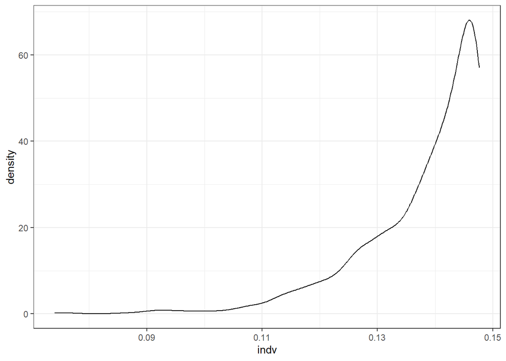

```r
# Individual level treatment effect: Risk Difference
indv_treat <- as.data.frame(cbind(mu1, mu0))
indv_treat %>%
  mutate(indv = mu1 - mu0) %>%
  as_tibble() |>
  ggplot(aes(x=indv)) +
  geom_density(alpha=0.5) +
  theme_bw()
```

**Tip**

This plots the **distribution of individual-level risk differences**: $\hat{Y}(1) - \hat{Y}(0)$ for each person.

> It visualizes **treatment effect heterogeneity** — even though G-computation estimates a marginal effect, this shows how it may vary across individuals.

# 5 Bootstrap confidence interval

```r
# Using the bootstrap to obtain confidence intervals for the marginally adjusted odd ratio, risk ratio, and risk difference.

bootfunc <- function(data, index) {
boot_dat <- data[index, ]
ms_model <- glm(modelForm, data = boot_dat,family = binomial("logit"))

mu1 <- predict(ms_model, newdata = transform(boot_dat,qsmk = 1), type = "response")
mu0 <- predict(ms_model, newdata = transform(boot_dat,qsmk = 0), type = "response")
marg_stand_OR_ <- (mean(mu1)/mean(1 -mu1))/(mean(mu0)/mean(1 - mu0))
marg_stand_RR_ <- mean(mu1)/mean(mu0)
marg_stand_RD_ <- mean(mu1) - mean(mu0)

res <- c(marg_stand_RD_, marg_stand_RR_,marg_stand_OR_)
return(res)
}

#' Run the boot function. Set a seed to obtain reproducibility
set.seed(123)
boot_res <- boot(nhefs, bootfunc, R = 2000)
boot_RD <- boot.ci(boot_res, index = 1)
boot_RR <- boot.ci(boot_res, index = 2)
boot_OR <- boot.ci(boot_res, index = 3)

# Bootstrap confidence interval
marg_stand_RD # estimate
```

```
[1] 0.1377615
```

```r
boot_RD # Boot CI
```

```
BOOTSTRAP CONFIDENCE INTERVAL CALCULATIONS
Based on 2000 bootstrap replicates

CALL :
boot.ci(boot.out = boot_res, index = 1)

Intervals :
Level      Normal              Basic
95%   ( 0.0793,  0.1966 )   ( 0.0802,  0.1976 )

Level     Percentile            BCa
95%   ( 0.0779,  0.1953 )   ( 0.0779,  0.1952 )
Calculations and Intervals on Original Scale
```

```r
marg_stand_OR
```

```
[1] 1.746213
```

```r
boot_OR
```

```
BOOTSTRAP CONFIDENCE INTERVAL CALCULATIONS
Based on 2000 bootstrap replicates

CALL :
boot.ci(boot.out = boot_res, index = 3)

Intervals :
Level      Normal              Basic
95%   ( 1.302,  2.162 )   ( 1.266,  2.125 )

Level     Percentile            BCa
95%   ( 1.367,  2.227 )   ( 1.367,  2.224 )
Calculations and Intervals on Original Scale
```

```r
marg_stand_RR
```

```
[1] 1.295328
```

```r
boot_RR
```

```
BOOTSTRAP CONFIDENCE INTERVAL CALCULATIONS
Based on 2000 bootstrap replicates

CALL :
boot.ci(boot.out = boot_res, index = 2)

Intervals :
Level      Normal              Basic
95%   ( 1.158,  1.431 )   ( 1.156,  1.428 )

Level     Percentile            BCa
95%   ( 1.163,  1.435 )   ( 1.163,  1.435 )
Calculations and Intervals on Original Scale
```

## 5.1 Interpretation

### 5.1.1 Summary of G-Computation Bootstrap Estimates

```
Bootstrap Statistics :
     original        bias       std. error
t1* 0.1377615   -0.0002023   0.02992375  # Risk Difference (RD)
t2* 1.2953277    0.0009546   0.06959698  # Risk Ratio (RR)
t3* 1.7462129    0.0144292   0.21935613  # Odds Ratio (OR)
```

> **t1* = Risk Difference (RD)**
- **Estimate**: 0.138 → The treated group has a **13.8 percentage point higher probability** of the outcome compared to the untreated group.
- **Bias**: practically zero (−0.0002) → your bootstrap distribution aligns well with the original estimate.
- **Standard error**: 0.030 → measure of variability across bootstrap samples.

> **t2* = Risk Ratio (RR)**
- **Estimate**: 1.295 → The **risk** of the outcome is **29.5% higher** in the treated group vs untreated.
- **Bias**: almost zero → model is stable.
- **SE**: ~0.070

> **t3* = Odds Ratio (OR)**
- **Estimate**: 1.746 → The **odds** of the outcome are **74.6% higher** in the treated group.
- **SE**: relatively large (0.219), which is normal since ORs tend to be less stable, especially in logistic models.
- **Bias**: small (0.014), but worth noting.

### 5.1.2 G-Computation Bootstrap Estimates and Confidence Intervals

#### 5.1.2.1 Output

```
> marg_stand_RD
[1] 0.1377615
> boot_RD
BOOTSTRAP CONFIDENCE INTERVAL CALCULATIONS
Based on 2000 bootstrap replicates

CALL :
boot.ci(boot.out = boot_res, index = 1)

Intervals :
Level      Normal              Basic
95%   ( 0.0793,  0.1966 )   ( 0.0802,  0.1976 )

Level     Percentile            BCa
95%   ( 0.0779,  0.1953 )   ( 0.0779,  0.1952 )
Calculations and Intervals on Original Scale
```

#### 5.1.2.2 Types of CI

- Which CI to Report?

| CI Type | Description |
| --- | --- |
| **Normal** | Based on normal approximation (not ideal for skewed estimates) |
| **Basic** | Adjusted for bootstrap bias |
| **Percentile** | Uses empirical percentiles of bootstrap distribution |
| **BCa** | **Bias-Corrected and Accelerated** — adjusts for both bias and skewness (often the best choice) |

- In most cases, the **BCa interval** is preferred because it’s more accurate, especially when the bootstrap distribution is skewed or biased.

#### 5.1.2.3 Summary and Conclusion

| Effect Type | Estimate | 95% CI (BCa) | Interpretation |
| --- | --- | --- | --- |
| **Risk Difference** (RD) | 0.138 | (0.078, 0.195) | Treated group has **13.8 percentage point higher** probability of outcome |
| **Risk Ratio** (RR) | 1.295 | (1.163, 1.435) | Treated group has **29.5% higher risk** of outcome |
| **Odds Ratio** (OR) | 1.746 | (1.367, 2.224) | Treated group has **74.6% higher odds** of outcome |

- Risk Difference (RD):
  - If everyone were treated (qsmk = 1), the probability of the outcome (e.g., weight gain) would increase by **13.8 percentage points**, compared to if no one were treated = ATE
  - This estimate is statistically significant, since the 95% CI does **not include 0**.
- Risk Ratio (RR):
  - The **risk** of the outcome is **29.5% higher** in the treated group than the untreated group.
  - The 95% CI **does not cross 1**, so the increase in risk is statistically significant.
- Odds Ratio (OR):
  - The **odds** of the outcome are **74.6% higher** in the treated group than in the untreated group.
  - Again, statistically significant since the 95% CI is entirely above 1.

# 6 Marginal Standardization Approach with Stratified Modeling

This stratified modeling approach avoids the exposure effect homogeneity assumption across levels of all the confounders. In effect, the approach fits a separate model for each exposure stratum.

## 6.1 Concepts

### 6.1.1 What is *Marginal Standardization*?

**Marginal Standardization** is a general technique used to estimate **population-level (marginal) effects** from regression models that are **conditional** on covariates.

It works by:

1. **Fitting a model conditional on covariates** (e.g., logistic regression `Y ~ X + C`),
2. **Predicting outcomes under each treatment level** for *every* individual in the data,
3. **Averaging those predicted outcomes** over the covariate distribution in your sample.
4. This is essentially **parametric G-computation**.

### 6.1.2 What is the *Stratified Modeling Version*?

The **“stratified modeling approach”** to marginal standardization means that instead of fitting one big regression model that includes **treatment + all covariates**, you **fit separate models within strata of the treatment variable**.

In other words: **Stratified Modeling:**

- Fit separate models:
  - One for the treated group: $\mathbb{E}[Y \mid C, X=1]$
  - One for the untreated group: $\mathbb{E}[Y \mid C, X=0]]$
- Use each model to predict the outcome under its respective treatment for the full sample
- Average the predicted outcomes (standardize over the covariate distribution)

This allows the treatment and covariates to interact **non-parametrically** — i.e., the effect of covariates on the outcome **can differ between treatment groups**.

#### 6.1.2.1 Why Stratify?

- It allows for **treatment effect heterogeneity** across strata (i.e., different regression functions for treated and untreated).
- Avoids imposing **homogeneous treatment effects** as in a single model with linear terms.
- Especially useful when you **suspect interaction effects** or **non-linearity** that a single model can’t capture well.

## 6.2 Demo with Epidemology Data

```r
#' Marginal Standardization
##' To avoid assuming no interaction between
##' quitting smoking and any of the other variables
##' in the model, we subset modeling among
##' exposed/unexposed. This code removes qsmk from the model,
##' which will allow us to regress the outcome
##' against the confounders among the exposed and
##' the unexposed separately. Doing so will allow us
##' to account for any potential exposure-covariate interactions
##' that may be present.

formulaVars <- "sex + age + income + sbp + dbp + price71 + tax71 + race"
modelForm <- as.formula(paste("wt_delta ~",formulaVars))
modelForm
```

```
wt_delta ~ sex + age + income + sbp + dbp + price71 + tax71 +
    race
```

```r
#' Regress the outcome against the confounders
#' among the unexposed (model0) and then among the exposed (model1)
model0 <- glm(modelForm, data = subset(nhefs,qsmk == 0), family = binomial("logit"))
model1 <- glm(modelForm, data = subset(nhefs,qsmk == 1), family = binomial("logit"))

##' Generate predictions for everyone in the sample using the model fit to only the
##' unexposed (mu0 predictions) and only the exposed (mu1 predictions).
mu1 <- predict(model1, newdata = nhefs, type = "response")
mu0 <- predict(model0, newdata = nhefs, type = "response")

#' Marginally adjusted odds ratio
marg_stand_OR <- (mean(mu1)/mean(1 - mu1))/(mean(mu0)/mean(1 -mu0))
marg_stand_OR
```

```
[1] 1.757907
```

```r
#' Marginally adjusted risk ratio
marg_stand_RR <- mean(mu1)/mean(mu0)
marg_stand_RR
```

```
[1] 1.298577
```

```r
#' Marginally adjusted risk difference
marg_stand_RD <- mean(mu1) - mean(mu0)
marg_stand_RD
```

```
[1] 0.139347
```

## 6.3 Bootstrap Confidence Intervals

```r
#' Using the bootstrap to obtain confidence intervals for the marginally adjusted
#' risk ratio and risk difference.

bootfunc <- function(data, index) {
boot_dat <- data[index, ]
model0 <- glm(modelForm, data = subset(boot_dat,qsmk == 0), family =binomial("logit"))
model1 <- glm(modelForm, data = subset(boot_dat,qsmk == 1), family =binomial("logit"))

mu1 <- predict(model1, newdata = boot_dat,type = "response")
mu0 <- predict(model0, newdata = boot_dat,type = "response")

marg_stand_OR_ <- (mean(mu1)/mean(1 -mu1))/(mean(mu0)/mean(1 - mu0))
marg_stand_RR_ <- mean(mu1)/mean(mu0)
marg_stand_RD_ <- mean(mu1) - mean(mu0)

res <- c(marg_stand_RD_, marg_stand_RR_,marg_stand_OR_)
return(res)
}


#' Run the boot function. Set a seed to obtain reproducibility
set.seed(123)
boot_res <- boot(nhefs, bootfunc, R = 2000)
boot_RD <- boot.ci(boot_res, index = 1)
boot_RR <- boot.ci(boot_res, index = 2)
boot_OR <- boot.ci(boot_res, index = 2)
marg_stand_OR
```

```
[1] 1.757907
```

```r
marg_stand_RR
```

```
[1] 1.298577
```

```r
marg_stand_RD
```

```
[1] 0.139347
```

```r
# Bootstrap confidence interval
boot_RD
```

```
BOOTSTRAP CONFIDENCE INTERVAL CALCULATIONS
Based on 2000 bootstrap replicates

CALL :
boot.ci(boot.out = boot_res, index = 1)

Intervals :
Level      Normal              Basic
95%   ( 0.0794,  0.1995 )   ( 0.0791,  0.1996 )

Level     Percentile            BCa
95%   ( 0.0791,  0.1996 )   ( 0.0790,  0.1995 )
Calculations and Intervals on Original Scale
```

```r
boot_RR
```

```
BOOTSTRAP CONFIDENCE INTERVAL CALCULATIONS
Based on 2000 bootstrap replicates

CALL :
boot.ci(boot.out = boot_res, index = 2)

Intervals :
Level      Normal              Basic
95%   ( 1.159,  1.436 )   ( 1.156,  1.432 )

Level     Percentile            BCa
95%   ( 1.165,  1.442 )   ( 1.164,  1.440 )
Calculations and Intervals on Original Scale
```

```r
boot_OR
```

```
BOOTSTRAP CONFIDENCE INTERVAL CALCULATIONS
Based on 2000 bootstrap replicates

CALL :
boot.ci(boot.out = boot_res, index = 2)

Intervals :
Level      Normal              Basic
95%   ( 1.159,  1.436 )   ( 1.156,  1.432 )

Level     Percentile            BCa
95%   ( 1.165,  1.442 )   ( 1.164,  1.440 )
Calculations and Intervals on Original Scale
```

## 6.4 Comparison: G-Computation vs Marginal Standardization via Stratified Modeling

| Feature | G-Computation (Parametric) | Stratified Marginal Standardization |
| --- | --- | --- |
| **Model Fit** | One model: `Y∼A+XY` | Two models: fit separately for each `X` |
| **Assumes Homogeneous Effects?** | Yes, unless interactions are included | No — allows effects of `C` to vary by `X` |
| **Predictions made for** | Both `X = 1` and `X = 0` for everyone | Same |
| **Counterfactual Simulation** | Yes | No |
| **Interpretation** | Marginal causal effects (ATE, RR, OR, etc.) | Same |
| **Flexibility** | Moderate (depends on model specification) | Higher (more robust to model misspecification) |

## 6.5 When to Use Which?

| Use G-Computation (1 model) if: |
| --- |
| You believe treatment effects are constant or linear w.r.t. covariates |
| You want simplicity or interpretability |
| You include interactions manually |

| Use Stratified Modeling if: |
| --- |
| You suspect treatment effect heterogeneity |
| You want more flexibility in model fit |
| You want to avoid functional form assumptions |